# Transformada Z

Renato Naville Watanabe

## Definição

A **transformada Z** (unilateral) de um sinal discreto $x[n]$ é:

$$X(z) = \displaystyle\sum_{n=0}^\infty x[n]z^{-n}$$

Repare que a somatória começa de $n=0$. Isso é porque usamos a definição de transformada Z unilateral. Existe uma outra definição (bilateral), menos usada, que começa de $n=-\infty$. A desvantagem da transformada Z unilateral é que só pode ser utilizada em sistemas causais. Como os sistemas encontrados na prática normalmente são causais, a transformada unilateral é mais usada, devido a sua maior simplicidade.

### Exemplo 1

Para o sinal $x[n] = \left(\frac{1}{2}\right)^nu[n]$, a transformda Z é:

$X(z) = \displaystyle\sum_{n=0}^\infty\left(\frac{1}{2}\right)^nu[n]z^{-n} =\displaystyle\sum_{n=0}^\infty\left(\frac{z^{-1}}{2}\right)^n$

Se $\left|\frac{z^{-1}}{2}\right|<1$ ($|z|>\frac{1}{2}$) a somatória converge. Esses valores para os quais a transformada Z converge ($|z|>\frac{1}{2}$ nesse caso) é conhecido como **região de convergência**. A região de convergência tem muita importância prática quando trabalhamos com a transformada Z bilateral, mas pouca importância na transformada Z unilateral. Por esse motivo, não nos preocuparemos com a região de convergência.

$X(z)= \frac{1}{1-\frac{z^{-1}}{2}} = \frac{2}{2-z^{-1}}$

### Transformada Z de alguns sinais

- $x[n] = \delta[n-k]$

$X(z) = \displaystyle\sum_{n=0}^\infty\delta[n-k]z^{-n} = z^{-k}$

- $x[n] = u[n]$

$X(z) = \displaystyle\sum_{n=0}^\infty u[n]z^{-n} = \frac{1}{1-z^{-1}} = \frac{z}{z-1}$

Abaixo segue uma tabela com alguns sinais encontrados frequentemente na prática:

[output not shown]

A demonstração de cada um dessas transformadas Z fica como exercício.

## Propriedades da transformada Z

### Atraso

- $x_1[n] = x[n-k]u[n-k]$

$X_1(z) = \displaystyle\sum_{n=0}^\infty x[n-k]z^{-n} = \displaystyle\sum_{w=0}^\infty x[w]z^{-w-k} = z^{-k}\displaystyle\sum_{n=0}^\infty x[w]z^{-w} = z^{-k}X(z)$

### Avanço

- $x_1[n] = x[n+k]u[n]$

$X_1(z) = z^kX(z) - z^k\displaystyle\sum_{n=0}^{k-1}x[n]z^{-n}$

### Convolução

A transformada Z da convolução entre dois sinais é uma das propriedades mais importantes na análise de sinais e sistemas lineares e invariantes no tempo.

$x_3[n] = x_1[n]*x_2[n] = \displaystyle\sum_{k=-\infty}^\infty x_1[k]x_2[n-k]$

Com $x_1[n] = 0$ para $n<0$ e $x_2[n] = 0$ para $n < 0$.

Então

$x_3[n] = \displaystyle\sum_{k=0}^\infty x_1[k]x_2[n-k]$

$X_3(z) = \displaystyle\sum_{n=0}^\infty x_3[n]z^{-n} = \displaystyle\sum_{n=0}^\infty z^{-n}\displaystyle\sum_{k=0}^\infty x_1[k]x_2[n-k] = \displaystyle\sum_{k=0}^\infty x_1[k]\displaystyle\sum_{n=0}^\infty z^{-n}x_2[n-k] = \displaystyle\sum_{k=0}^\infty x_1[k]\displaystyle\sum_{r=0}^\infty z^{-r-k}x_2[r] = \displaystyle\sum_{k=0}^\infty x_1[k]z^{-k}\displaystyle\sum_{r=0}^\infty z^{-r}x_2[r]$

Então, a transformada Z da convolução entre dois sinais é a multiplicação das transformadas Z de cada um dos sinais:

$X_3(z) = X_1(z)X_2(z)$

### Linearidade

A transformada Z é uma operação linear. Ou seja, valem as seguintes propriedades:

$$\mathcal{Z}(x_1[n]) = X_1(z) \text{ e } \mathcal{Z}(x_2[n]) = X_2(z)$$

Então,

$$\mathcal{Z}(x_1[n]+x_2[n]) = X_1(z) + X_2(z)$$

e

$$\mathcal{Z}(\alpha x_1[n]) = \alpha X_1(z)$$

As provas dessas propriedades saem facilmente considerando que a transformada Z é definida como um somatório, que é linear.

## Polos e zeros

Na maioria dos sinais encontrados na prática, as transformadas Z encontradas tem a forma de uma função racional (quociente de dois polinômios), na forma:

$$X(z) = \frac{b_Mz^{-M} +...+b_2z^{-2}+b_1z^{-1} + b_0}{1 + a_{1}z^{-1}+...+a_Nz^{-N}}$$

Pelo Teorema Fundamental da Álgebra, qualquer polinômio de grau $n$ tem $n$ raízes, e consequentemente a transformada Z pode ser reescrita da seguinte forma:

$X(z) = \frac{A(z-z_1)(z-z_2)...(z-z_M)}{(z-p_1)(z-p_2)...(z-p_N)}$

Os valores $z_i$ são as raízes do polinômio no numerador de $X(z)$. Esses valores são conhecidos como **zeros** de X(z). Os valores $p_i$ são as raízes do polinômio no denominador de $X(z)$. Esses valores são conhecidos como **polos** de X(z). Por fim, $A$ é uma constante.

### Exemplo 2

A transformada $X(z)$ dada pela seguinte expressão:

$$X(z) = \frac{z^2-0.3z-0.1}{z^3+0.2z^2-0.11z-0.012}$$

$X(z)$ pode ser reescrito da seguinte forma, com seus polos e zeros sendo mostrados explicitamente:

$$X(z) = \frac{(z-0.5)(z+0.2)}{(z+0.1)(z+0.4)(z-0.3)}$$

### Exemplo 3

A transformada z, mostrada abaixo:

$X(z) = \frac{z+0.2}{z^3-0.5z^2+0.33z-0.029}$

$X(z)$ pode ser reescrito na forma de polos e zeros como:

$X(z) = \frac{z+0.2}{(z-0.1)(z-0.2 - j0.5)(z-0.2+j0.5)}$

## Exercícios

**1)** Encontre a Transformada Z de cada um dos sinais abaixo:

a) $x_1[n] = \delta[n]$

b) $x_2[n] = u[n-k]$

c) $x_3[n] = nu[n]$

d) $x_4[n] = n^2u[n]$

e) $x_5[n] = n^3u[n]$

**2)** Encontre a Transformada Z de cada um dos sinais abaixo:

a) $x_1[n] = \alpha^nu[n]$

b) $x_2[n] = n\alpha^nu[n]$

c) $x_3[n] = \alpha^n\cos(\beta n)u[n]$, $\alpha>0$

d) $x_4[n] = r\alpha^n\cos(\beta n+\theta)u[n]$, $\alpha>0$

**3)** Encontre a transformada Z dos seguintes sinais:

a) $x_1[n] = u[n] - u[n-20]$

b) $x_2[n] = 0.5^n(u[n]-u[n-15])$

c) $x_3[n] = (-0.2)^n(u[n]-u[n-20])$

**4)** Calcule a transformada Z dos seguintes sinais:

a) $x_1[n] = \frac{\alpha^n}{n!}u[n]$

b) $x_2[n] = (3^{n-1}-(-3)^{n-1})u[n]$

c) $x_3[n] = \frac{(\ln(\alpha))^n}{n!}u[n]$

d) $x_4[n] = ne^{-3n}u[n-m]$

**5)** Determine a transformada Z do sinal no gráfico abaixo:

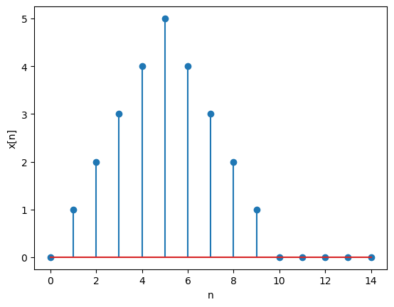

## Referências

- Ulaby, FT e Yagle, AE, Signals & Systems: Theory and Applications, 2018, ss2.eecs.umich.edu
- Lathi, BP, Sinais e Sistemas Lineares, 2007
- Oppenheim, M. e Willsky, S., Sistemas e Sinais, 2010
- Stewart, James. Cálculo - Volume 2, 2017
- Brown, James, e Ruel Churchill. Variáveis complexas e aplicações. (9ª edição), 2015.